# CH4_submit_3

##### **CSPB 4830 - Special Topics: Coding Calculus**

### **Week #4 Workbook**

**Stephen Enriquez (@sten8791)**

Week 4 Activities:

1. Your goal is to create a function or code snippet you can use to find the slope at a point of any function numerically.

Return to last week’s activity, #3, page 131 and make the following modifications:

Rename this function or routine “Numerical_Point_Derivative”

Choose a small h to use. “h = ...”

Add a line to enter an algebraic function, like x^2, or sin(x), or 3x^4 - 2x.

Add a line “a = ...” to enter the x value where you want to find the slope.

Choose one of the 2 methods to calculate the slope of a function at a single point. Add a code comment to tell me why you chose the formula you did.

Return the slope/rate of change/derivative of the function at point a.

Test it out with function/point examples from #10 page 133.

Keep it simple!

```python
# we parameterize 'a', h' and 'func' to allow ease of use within the Jupyer notebook
def Numerical_Point_Derivative(a, h, func):
    # Our analysis last week confirmed that the most accurate estimates of the slope were given
    # by the 'difference quotient' formula as defined in Ch.3 p.120
    # This formula is also referred to as the "central difference" formula
    difference_quotient = (func(a + h) - func(a - h)) / (2 * h)
    return difference_quotient
```

Now let's try it out with the following functions given in #10:

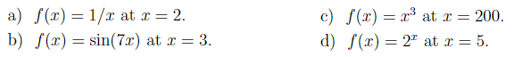

Let's define these functions so we can call them with our derivative function:

```python
def x_cubed(x):
    y = x ** 3
    return y

def inverse(x):
    y = 1 / x
    return y

def sin_7x(x):
    import numpy as np
    y = np.sin(7 * x)
    return y

def two_exp(x):
    y = 2 ** x
    return y
```

Now let's try calling our derivative function for the sample functions above.

a. f(x) = 1/x at x = 2

```python
print(Numerical_Point_Derivative(2, 0.0002, inverse))
```

```
-0.25000000249991716
```

b. f(x) = sin(7x) at x = 3

```python
print(Numerical_Point_Derivative(3, 0.0002, sin_7x))
```

```
-3.8341035690964143
```

c. f(x) = x^3 at x = 200

```python
print(Numerical_Point_Derivative(200, 0.0002, x_cubed))
```

```
120000.00000465661
```

d. f(x) = 2^x at x = 5

```python
print(Numerical_Point_Derivative(5, 0.0002, two_exp))
```

```
22.180709849006774
```

2. Search the internet for a “Numerical Derivative calculator.” Compare your results with the tool you found. How did you do?

We use the numerical derivative calculator at [Wolfram Alpha](https://www.wolframalpha.com) to compare our results from part 1.

a. f(x) = 1/x at x = 2

Calculated value from part (1) : **-0.25000000249991716**

Calculator value from Wolfram Alpha: **-0.25**

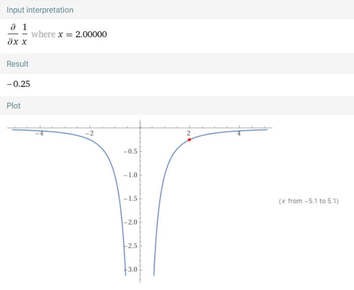

b. f(x) = sin(7x) at x = 3

Calculated value from part (1) : **-3.8341035690964143**

Calculator value from Wolfram Alpha: **-3.8341**

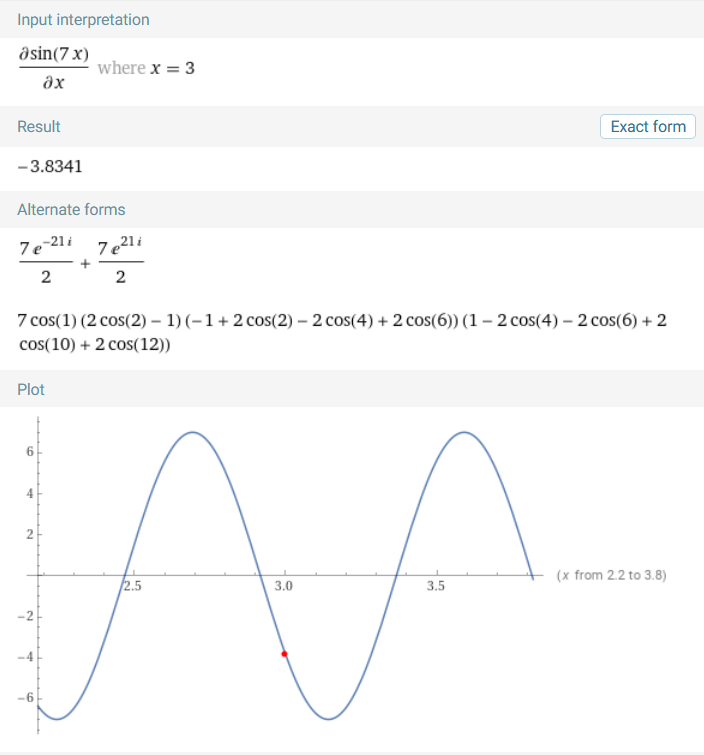

c. f(x) = x^3 at x = 200

Calculated value from part (1) : **120000.00000465661**

Calculator value from Wolfram Alpha: **120000**

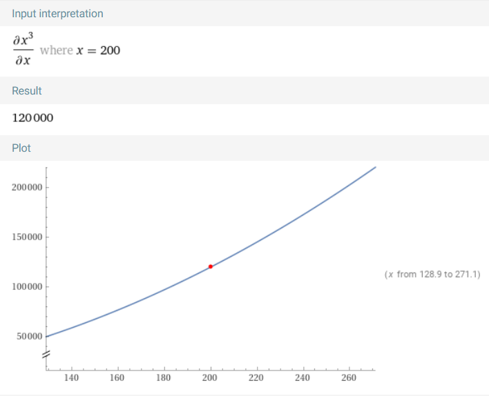

d. f(x) = 2^x at x = 5

Calculated value from part (1) : **22.180709849006774**

Calculator value from Wolfram Alpha: **22.1807**

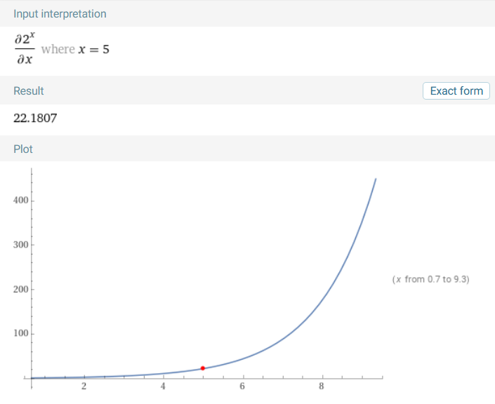

Overall, I think our calculated numeric value is the same as the one given by the calculator except with a higher degree of accuracy.

**Extra Optional Opportunity**

Can you figure out which method and what h the tool you found is using? I am not sure you can because of today’s computing power, but it might be interesting to try.

We write the following code to plot the performance of the tangent and secant functions against the estimate given to us by the WolframAlpha calculator. We also tabulate the derivative estimates to help evaluate the 'h' value that the WolframAlpha calculator might be using.

```python
def examine_H(func, function_description, a, calculator_estimate, include_plots):
    from tabulate import tabulate
    import matplotlib.pyplot as plt
    h_ = []
    secant_ = []
    tangent_ = []
    calculator_ = []

    for k in range(1,10):
        h = (0.5) ** k
        secant = (func(a + h) - func(a - h)) / (2 * h)
        tangent = ((func(a + h) - func(a)) / (h))
        h_.append(h)
        secant_.append(secant)
        tangent_.append(tangent)
        calculator_.append(calculator_estimate) # use in tabulate

    # tabulate results
    print(tabulate({"h": h_, "secant": secant_, "tangent": tangent_, "calculator": calculator_}, headers = "keys"))

    #plot the calculator estimate
    x_ = [h_[0], h_[-1]]
    y_ = [calculator_estimate, calculator_estimate]
    plt.plot(x_, y_, label="Wolfram Alpha", marker='o', linestyle='--', color = 'red')
    # only graph plots in include_plot list
    if 1 in include_plots:
        plt.plot(h_, secant_, label="Secant", marker='o', color = 'blue')
    if 2 in include_plots:
        plt.plot(h_, tangent_, label="Tangent", marker='o', color = 'purple')
    plt.xscale("log")
    plt.xlabel("h (log)")
    plt.ylabel("Slope Estimate")

    ax = plt.gca()

    plt.title(f"{function_description} at x = {a}")
    plt.grid(True)
    plt.legend()
    plt.show()
```

Now let's check these against the functions we've run in the previous section:

a. f(x) = 1/x at x = 2

Calculated value from part (1) : **-0.25000000249991716**

Calculator value from Wolfram Alpha: **-0.25**

```
         h     secant    tangent    calculator
----------  ---------  ---------  ------------
0.5         -0.266667  -0.2              -0.25
0.25        -0.253968  -0.222222         -0.25
0.125       -0.25098   -0.235294         -0.25
0.0625      -0.250244  -0.242424         -0.25
0.03125     -0.250061  -0.246154         -0.25
0.015625    -0.250015  -0.248062         -0.25
0.0078125   -0.250004  -0.249027         -0.25
0.00390625  -0.250001  -0.249513         -0.25
0.00195312  -0.25      -0.249756         -0.25
```

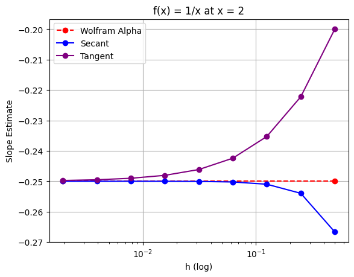

```python
examine_H(inverse, "f(x) = 1/x", 2, -0.25, (1,2))
```

b. f(x) = sin(7x) at x = 3

Calculated value from part (1) : **-3.8341035690964143**

Calculator value from Wolfram Alpha: **-3.8341**

```
         h     secant    tangent    calculator
----------  ---------  ---------  ------------
0.5          0.384268   -2.85603       -3.8341
0.25        -2.15583    -6.09898       -3.8341
0.125       -3.36325    -5.76614       -3.8341
0.0625      -3.71296    -4.97378       -3.8341
0.03125     -3.8036     -4.44161       -3.8341
0.015625    -3.82646    -4.14643       -3.8341
0.0078125   -3.83219    -3.9923        -3.8341
0.00390625  -3.83363    -3.91369       -3.8341
0.00195312  -3.83399    -3.87402       -3.8341
```

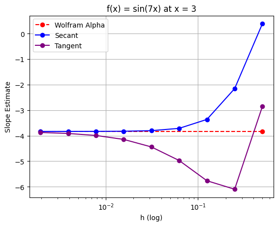

```python
examine_H(sin_7x, "f(x) = sin(7x)", 3, -3.8341, (1,2))
```

c. f(x) = x^3 at x = 200

Calculated value from part (1) : **120000.00000465661**

Calculator value from Wolfram Alpha: **120000**

```
         h    secant    tangent    calculator
----------  --------  ---------  ------------
0.5           120000     120300        120000
0.25          120000     120150        120000
0.125         120000     120075        120000
0.0625        120000     120038        120000
0.03125       120000     120019        120000
0.015625      120000     120009        120000
0.0078125     120000     120005        120000
0.00390625    120000     120002        120000
0.00195312    120000     120001        120000
```

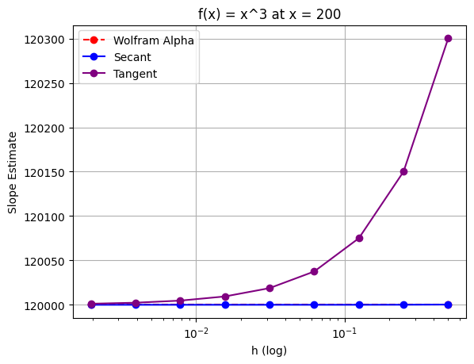

```python
examine_H(x_cubed, "f(x) = x^3", 200, 120000, (1,2))
```

d. f(x) = 2^x at x = 5

Calculated value from part (1) : **22.180709849006774**

Calculator value from Wolfram Alpha: **22.1807**

```
         h    secant    tangent    calculator
----------  --------  ---------  ------------
0.5          22.6274    26.5097       22.1807
0.25         22.2919    24.2185       22.1807
0.125        22.2085    23.17         22.1807
0.0625       22.1876    22.6682       22.1807
0.03125      22.1824    22.4227       22.1807
0.015625     22.1811    22.3013       22.1807
0.0078125    22.1808    22.2409       22.1807
0.00390625   22.1807    22.2108       22.1807
0.00195312   22.1807    22.1957       22.1807
```

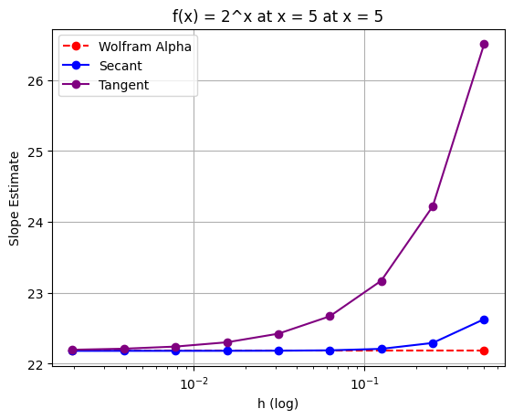

```python
examine_H(two_exp, "f(x) = 2^x at x = 5", 5, 22.1807, (1,2))
```

**Analysis**

From the graphs above, it looks like the **secant** method is being used by Wolfram Alpha. From the graphs above, we observe that the secant method is more accurate than the tangent method. The secant graph approaches the value we calculated from part 1 at larger values of h, compared to the tangent graph.

It looks like we can give a reasonable estimate that the Wolfram Alpha calculator uses an h-value of **h = 0.005**.

3. Read section 3.5 and do #2 and #5 (pages 151, 152)

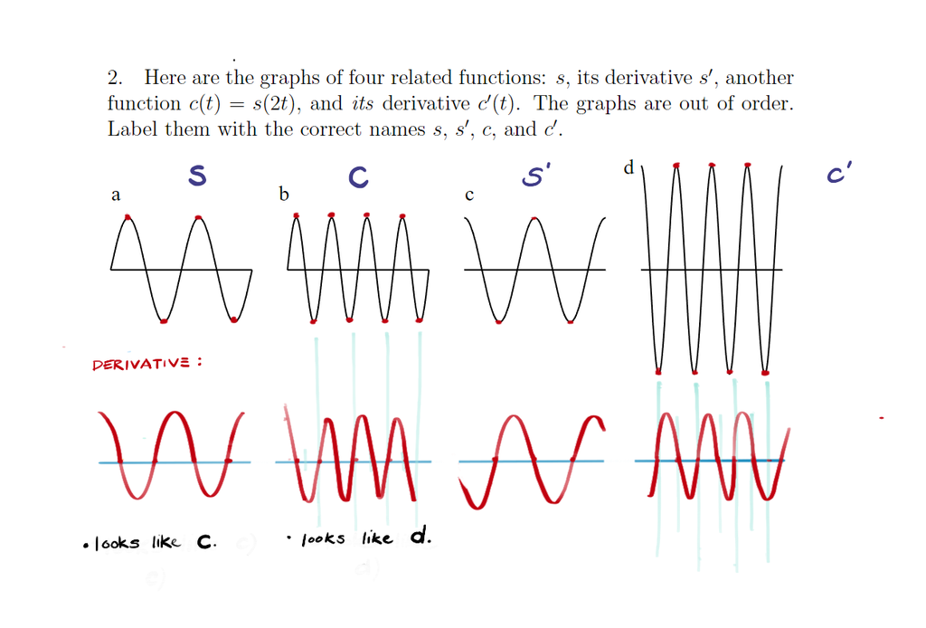

a. s

b. c

c. s'

d. c'

We start off by plotting an estimate of what the graph of the derivative would look like for the given plots.

By experimenting with a graphing calculator, we can say that sin(2t) would have half the wavelength of sin(t), which points to graph b being s(2t).

We refer to the table from p. 146 when making observations for #5 below.

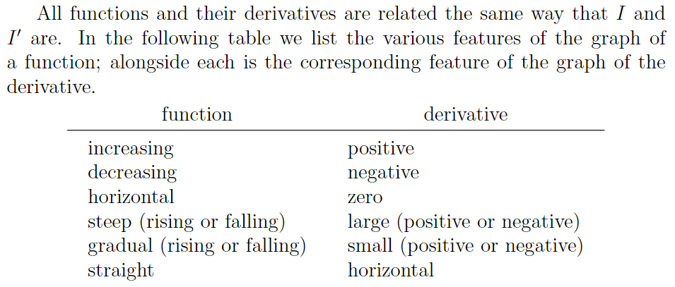

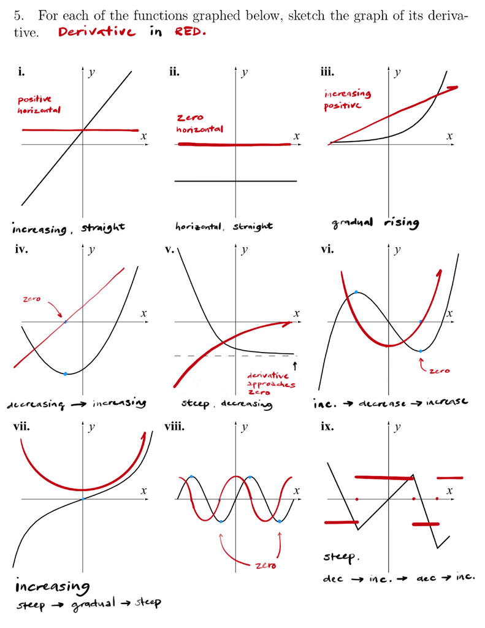

4. Copy and Modify your code in #1 to calculate the derivative at multiple points (at 20 points) over an x- interval from 1 to 3 and graph the results. You will now get an approximation to the graph of the derivative function. Call this new code “Numerical_Function_Derivative” Use the same examples from #10 page 133.

```python
# we parameterize 'a', h' and 'func' to allow ease of use within the Jupyer notebook
def Numerical_Function_Derivative(h, func, function_description):
    import numpy as np
    import matplotlib.pyplot as plt

    x_ = np.linspace(1, 3, 20)
    derivative_ = []

    for x in x_:
        derivative = (func(x + h) - func(x - h)) / (2 * h)
        derivative_.append(derivative)

    plt.plot(x_, derivative_, label="Derivative", marker='o', color = 'blue')
    plt.xlabel("x")
    plt.ylabel("Derivative")
    plt.title(f"{function_description}")
    plt.grid(True)
    #plt.legend()
    plt.show()
```

Now let's try it with some examples.

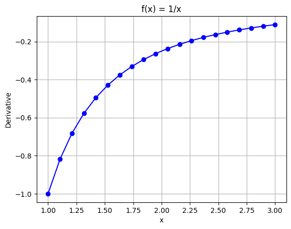

```python
Numerical_Function_Derivative(0.001, inverse, "f(x) = 1/x")
```

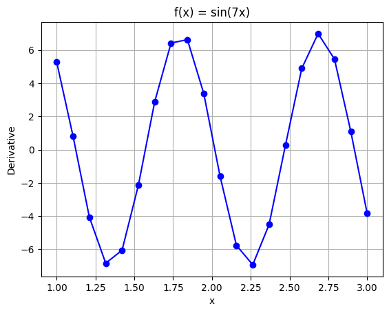

```python
Numerical_Function_Derivative(0.001, sin_7x, "f(x) = sin(7x)")
```

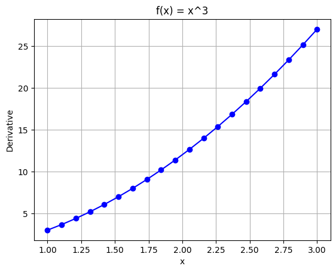

```python
Numerical_Function_Derivative(0.001, x_cubed, "f(x) = x^3")
```

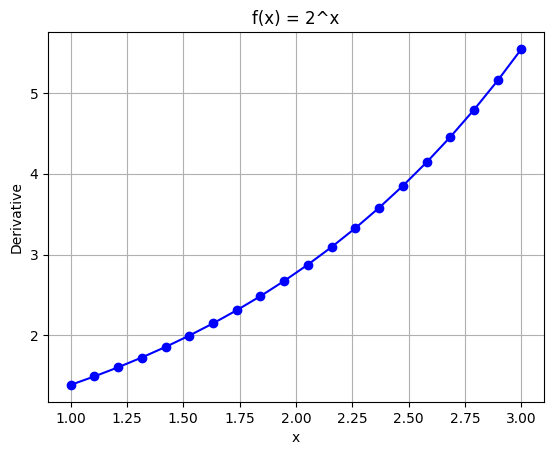

```python
Numerical_Function_Derivative(0.001, two_exp, "f(x) = 2^x")
```

5. Finally, here are the actual “function” derivatives of the function from #10.

   f(x) = 1/x ; f’(x) = -1 / x^2

   f(x) = sin(7x) ; f’(x) = 7 cos(7x)

   f(x) x^3 ; f’(x) = 3 x^2

   f(x) = 2^x ; f’(x) = ln2 * 2^x

Graph these f’(x) functions on the interval (1,3), how do they compare to your numerical results? Are 20 samples enough to graph the derivative on this interval? (you can code these or just use Demos.com and see if you got the same shape. What’s tricky about b)? )

We write the following function to plot our estimated derivative against the given actual "function" derivatives.

```python
def compare_functions(func_1, func_1_description, func_2, func_2_description, h, steps):
    import numpy as np
    import matplotlib.pyplot as plt

    x_ = np.linspace(1, 3, steps)
    derivative_ = []
    actual_derivative_ = []

    for x in x_:
        derivative = (func_1(x + h) - func_1(x - h)) / (2 * h)
        actual_derivative = (func_2(x))
        derivative_.append(derivative)
        actual_derivative_.append(actual_derivative)

    plt.plot(x_, derivative_, label=f"{func_1_description}", marker=7, color = 'red')
    plt.plot(x_, actual_derivative_, label=f"{func_2_description}", marker=6, color = 'blue')
    plt.xlabel("x")
    plt.ylabel("y")
    plt.title(f"{func_1_description}   vs.   {func_2_description}")
    plt.grid(True)
    plt.legend()
    plt.show()
```

We also define functions below for each of the actual "function" derivatives given to us.

```python
import numpy as np
def func_1(x):
    return (-1 / (x ** 2))

def func_2(x):
    return (7 * np.cos(7 * x))

def func_3(x):
    return (3 * (x ** 2))

def func_4(x):
    return (np.log(2) * (2 ** x))
```

In the plots below, we use red and blue caret marks which point to the data points to help us easily identify the plots in places where the graphs overlap.

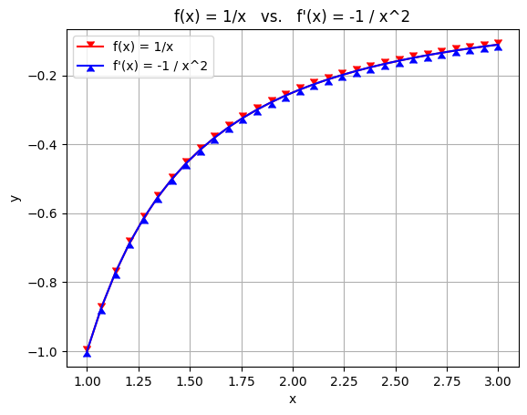

```python
compare_functions(inverse, "f(x) = 1/x", func_1, "f'(x) = -1 / x^2", 0.001, 30)
```

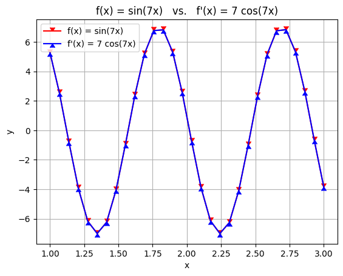

```python
compare_functions(sin_7x, "f(x) = sin(7x)", func_2, "f'(x) = 7 cos(7x)", 0.001, 30)
```

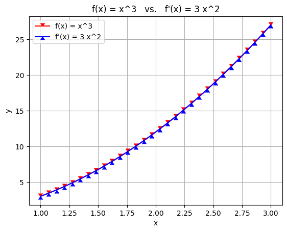

```python
compare_functions(x_cubed, "f(x) = x^3", func_3, "f'(x) = 3 x^2", 0.001, 30)
```

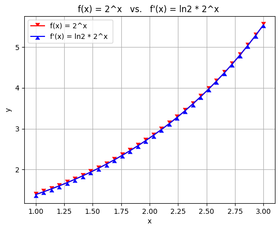

```python
compare_functions(two_exp, "f(x) = 2^x", func_4, "f'(x) = ln2 * 2^x ", 0.001, 30)
```

Graph these f’(x) functions on the interval (1,3), how do they compare to your numerical results? Are 20 samples enough to graph the derivative on this interval? (you can code these or just use Demos.com and see if you got the same shape. What’s tricky about b)? )

Looking at the graphs above, our graphs of the given derivative function look **identical** to our calculated numerical values. This confirms that our calculations for the difference quotient with the secant formula as an approximation for the derivative is very accurate.

As for sample size, 30 steps seems sufficient for most of the graphs except for the the graph for f'(x) = 7 cos(7x). Due to the sinusoidal nature of the plot, it can be hard to identify exactly where the peaks and dips are on the graph with a small step value. If we plot the same graph with a higher step value, the graph looks much smoother and we can more asily identify and measure the ciritcal points on the graph.

Running the same graph but with double the steps (60) results in a much smoother and more easily readable graph:

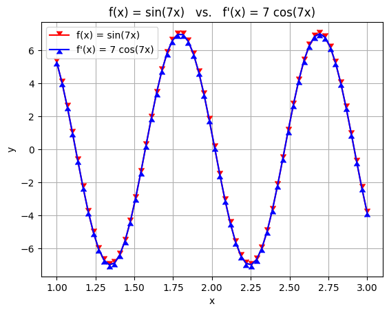

```python
compare_functions(sin_7x, "f(x) = sin(7x)", func_2, "f'(x) = 7 cos(7x)", 0.001, 60)
```